# Pós-graduação em Ciências Veterinárias (IV/UFRRJ)

Lista 3: Modelo de Regressão Logística - MRLog

Adriana Andrade Wagner Tassinari

2021

```r
# Importando os dados
library(readr)
banco<- read_csv2("G:/Meu Drive/Projects/MLG_2021/Listas/berneglm.csv")
```

```
## i Using "','" as decimal and "'.'" as grouping mark. Use `read_delim()` for more control.
```

```r
str(banco)
```

```
## spec_tbl_df [720 x 7] (S3: spec_tbl_df/tbl_df/tbl/data.frame)
##  $ Animal: num [1:720] 1 2 3 4 5 6 7 8 9 10 ...
##  $ M     : chr [1:720] "Jan" "Jan" "Jan" "Jan" ...
##  $ Tem   : num [1:720] 25.7 25.7 25.7 25.7 25.7 25.7 25.7 25.7 25.7 25.7 ...
##  $ Pre   : num [1:720] 151 151 151 151 151 ...
##  $ Umi   : num [1:720] 66.7 66.7 66.7 66.7 66.7 66.7 66.7 66.7 66.7 66.7 ...
##  $ dh    : num [1:720] 0 3 2 2 6 0 4 1 2 4 ...
##  $ local : num [1:720] 1 1 1 1 1 1 1 1 1 1 ...
##  - attr(*, "spec")=
##   .. cols(
##   ..   Animal = col_double(),
##   ..   M = col_character(),
##   ..   Tem = col_double(),
##   ..   Pre = col_double(),
##   ..   Umi = col_double(),
##   ..   dh = col_double(),
##   ..   local = col_double()
##   .. )
##  - attr(*, "problems")=<externalptr>
```

## Verificação de valores ausentes

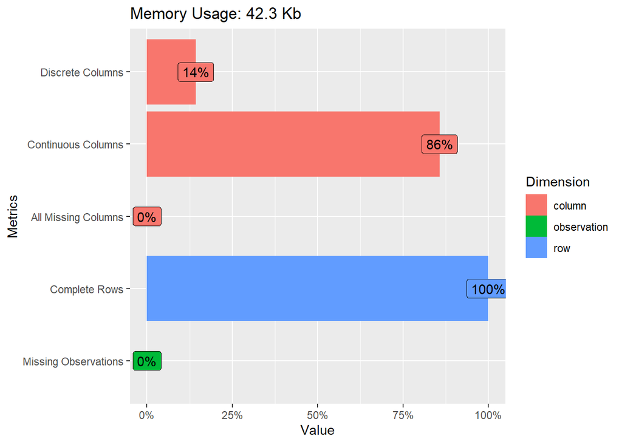

```r
#Verificação de Missing values na base de dados

library(DataExplorer)

plot_intro(banco)
```

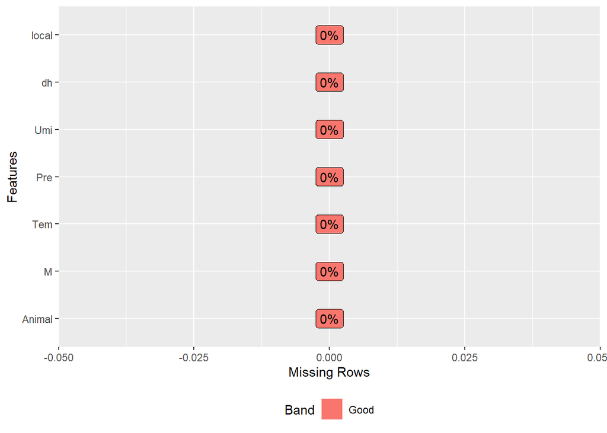

```r
plot_missing(banco)
```

##Categorização da variável Contagem de berne

```r
summary(banco$dh)
```

```
##    Min. 1st Qu.  Median    Mean 3rd Qu.    Max.
##   0.000   1.000   4.000   6.997  10.000  59.000
```

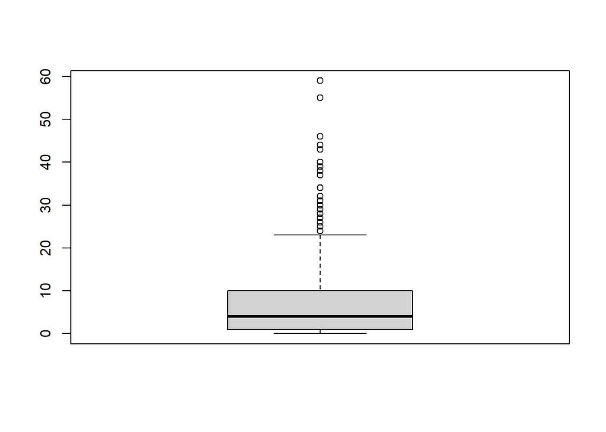

```r
boxplot(banco$dh)
```

```r
#Criação da variável categórica
banco$dh.x[banco$dh==0]<-0
banco$dh.x[banco$dh!=0]<-1
banco$dh.x<-factor(banco$dh.x,labels = c("Sim","Nao"))
banco$dh.x<-relevel(banco$dh.x,"Nao")
```

## Análise Exploratória

```r
library(tableone)

# Selecionando as variaveis que irao compor a tabela

myVars <- c("Tem","Pre","Umi")

## criando o objeto da TableOne

tabela1 <- CreateTableOne(vars = myVars, strata="dh.x", data = banco)

print(tabela1, showAllLevels = TRUE)
```

```
##                  Stratified by dh.x
##                   level Nao            Sim           p      test
##   n                        595           125
##   Tem (mean (SD))        23.97 (2.33)  23.72 (2.40)   0.280
##   Pre (mean (SD))       102.70 (67.42) 77.97 (53.14) <0.001
##   Umi (mean (SD))        74.30 (4.12)  73.44 (3.38)   0.028
```

## Estimação do Modelo

Primeiramente, será ajustado um modelo com todas as variáveis quantitativas e um segundo modelo com a exclusão das variáveis que não apresentaram coeficientes significativos. Foi criado ainda um modelo sem variávieis para fins de comparação.

```r
#Modelo com todas as variáveis quantitativas
mrlog1<-glm(dh.x~Tem +Pre +Umi, family = "binomial",data=banco)
summary(mrlog1)
```

```
##
## Call:
## glm(formula = dh.x ~ Tem + Pre + Umi, family = "binomial", data = banco)
##
## Deviance Residuals:
##     Min       1Q   Median       3Q      Max
## -0.8845  -0.6745  -0.5300  -0.4398   2.2099
##
## Coefficients:
##              Estimate Std. Error z value Pr(>|z|)
## (Intercept) -0.016219   3.057400  -0.005  0.99577
## Tem          0.051585   0.057157   0.903  0.36679
## Pre         -0.006952   0.002170  -3.203  0.00136 **
## Umi         -0.029059   0.030674  -0.947  0.34345
## ---
## Signif. codes:  0 '***' 0.001 '**' 0.01 '*' 0.05 '.' 0.1 ' ' 1
##
## (Dispersion parameter for binomial family taken to be 1)
##
##     Null deviance: 664.66  on 719  degrees of freedom
## Residual deviance: 645.88  on 716  degrees of freedom
## AIC: 653.88
##
## Number of Fisher Scoring iterations: 4
```

```r
#Modelo sem variáveis que não apresentaram coeficientes significativos
mrlog2<-glm(dh.x~Pre, family = "binomial",data=banco)
summary(mrlog2)
```

```
##
## Call:
## glm(formula = dh.x ~ Pre, family = "binomial", data = banco)
##
## Deviance Residuals:
##     Min       1Q   Median       3Q      Max
## -0.7788  -0.6956  -0.5436  -0.4573   2.2691
##
## Coefficients:
##              Estimate Std. Error z value Pr(>|z|)
## (Intercept) -1.000367   0.167675  -5.966 2.43e-09 ***
## Pre         -0.006231   0.001654  -3.768 0.000165 ***
## ---
## Signif. codes:  0 '***' 0.001 '**' 0.01 '*' 0.05 '.' 0.1 ' ' 1
##
## (Dispersion parameter for binomial family taken to be 1)
##
##     Null deviance: 664.66  on 719  degrees of freedom
## Residual deviance: 649.27  on 718  degrees of freedom
## AIC: 653.27
##
## Number of Fisher Scoring iterations: 4
```

```r
#Estimação do modelo vazio para fins de comparação
mrlog.vazio<-glm(dh.x~ 1, family = "binomial",data=banco)
```

## Medida de Qualidade do Modelo

Com base no teste da Razão de Verossimilhanças, tem-se evidências de que o modelo com a variável precipitação média é diferente do modelo vazio.

```r
library("lmtest")
lrtest(mrlog.vazio,mrlog2)
```

```
## Likelihood ratio test
##
## Model 1: dh.x ~ 1
## Model 2: dh.x ~ Pre
##   #Df  LogLik Df  Chisq Pr(>Chisq)
## 1   1 -332.33
## 2   2 -324.63  1 15.388  8.755e-05 ***
## ---
## Signif. codes:  0 '***' 0.001 '**' 0.01 '*' 0.05 '.' 0.1 ' ' 1
```

#### Utilizando algumas métricas de ajuste para comprar os modelos

A qualidade do ajuste do modelo com a variável apresentou uma perfamnce superior ao modelo sem variáveis com base no critério AIC e no pseudo R2.

```r
AIC(mrlog.vazio)
```

```
## [1] 666.6552
```

```r
AIC(mrlog2)
```

```
## [1] 653.2675
```

```r
library(blorr)
blr_rsq_nagelkerke(mrlog.vazio)
```

```
## [1] 0
```

```r
blr_rsq_nagelkerke(mrlog2)
```

```
## [1] 0.03508236
```

## Validação do Modelo - Teste de Hosmer e Lemeshow

Essa etapa de validação ganha importância quando o objetivo é fazer predições. Com base no teste de Hormer e Lemeshow, rejeitamos a hipótese de que os valores observados são iguais aos valores esperados, calculados a partir da modelagem, e temos um indicativo de que o modelo apresenta problemas relacionados com a predição do desfecho.

```r
library(blorr)
blr_test_hosmer_lemeshow(mrlog2)
```

```
##            Partition for the Hosmer & Lemeshow Test
## --------------------------------------------------------------
##                         def = 1                 def = 0
## Group    Total    Observed    Expected    Observed    Expected
## --------------------------------------------------------------
##   1       90         6          8.00         84        82.00
##   2       60         5          6.94         55        53.06
##   3       90         8         11.64         82        78.36
##   4       60         7          8.43         53        51.57
##   5       87         29        15.08         58        71.92
##   6       63         16        12.45         47        50.55
##   7       60         14        12.75         46        47.25
##   8       90         18        19.64         72        70.36
##   9       60         9         14.73         51        45.27
##  10       60         13        15.35         47        44.65
## --------------------------------------------------------------
##
##      Goodness of Fit Test
## ------------------------------
## Chi-Square    DF    Pr > ChiSq
## ------------------------------
##  23.3068      8       0.0030
## ------------------------------
```

## Validação do Modelo - Curva ROC

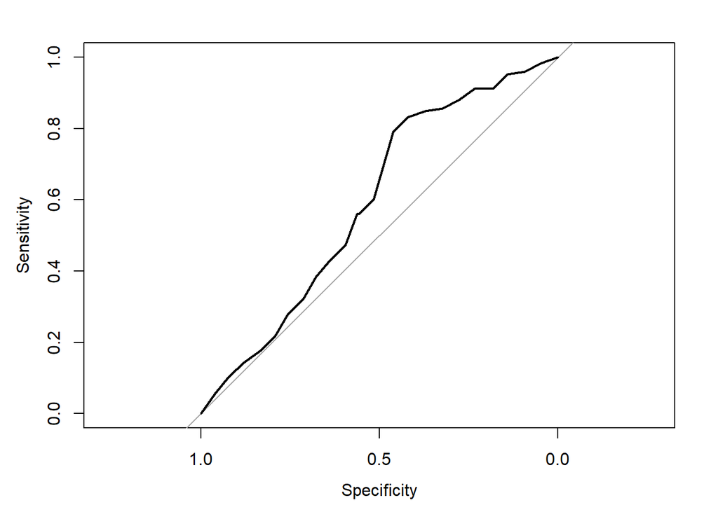

```r
library(pROC)
roc1<- plot.roc(banco$dh.x,fitted(mrlog2))
```

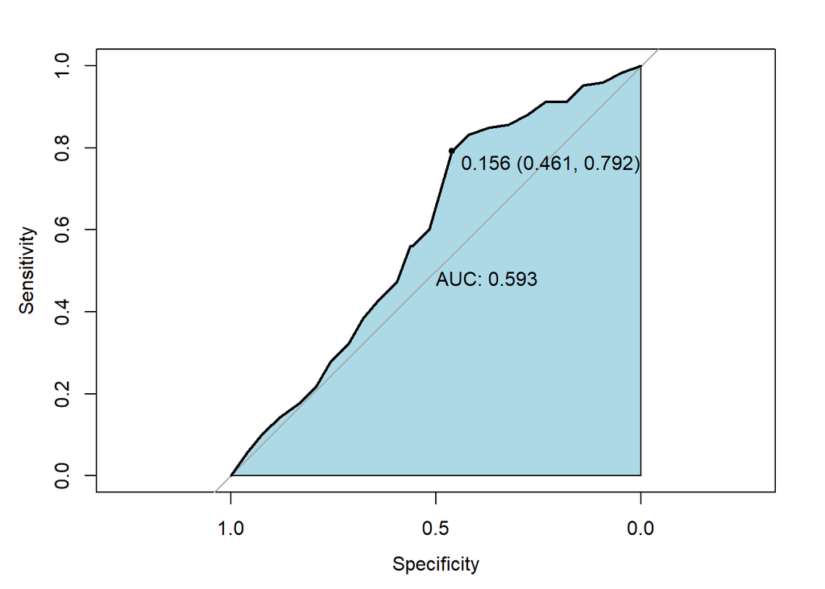

```r
plot(roc1,
     print.auc=TRUE,
     auc.polygon=TRUE,
     auc.polygon.col="lightblue",
     print.thres=TRUE
     )
```

# Adequação do Ajuste

Em termos da adequação do modelo com relação aos pressupostos, será verificada apenas a presença de pontos de alavanca. A multicolinieradidade não será testada pois há apenas uma variável no modelo. O gráfico releva que não há observações influentes.

## Verificação de outliers

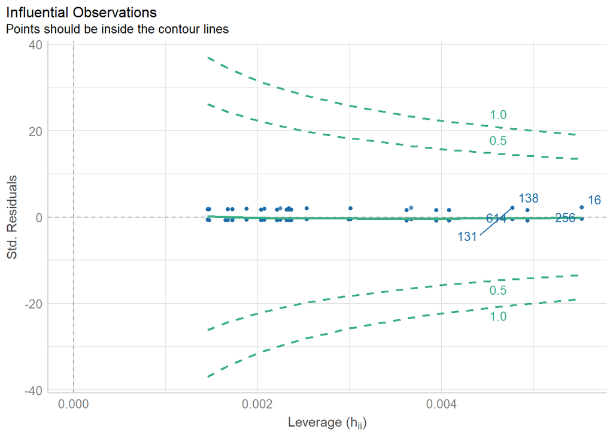

```r
library(performance)
plot(check_outliers(mrlog2))
```

# Análise do modelo

Equação do modelo

$ln \left ( \frac{\hat{p}_{dh}}{1-\hat{p}_{dh}} \right )=\hat{\beta}_0 +\hat{\beta}_{1}pred$

## Interpretação dos coeficientes do modelo

|  | Modelo Ajustado |  |  |
| --- | --- | --- | --- |
| Predictors | exp(B) | IC 95% | p-valor |
| (Intercept) | 0.37 | 0.26 – 0.51 | **<0.001** |
| Pre | 0.99 | 0.99 – 1.00 | **<0.001** |